# GAM Binary

Master Data Science: Verónica Gómez, Carlos Grande, Pablo Olmos

2020

# 2. Modelo GAM. Variable Dependiente Binaria.

Vamos a trabajar el modelo GAM con una variable Binaria

### Cargamos los Data Sets

```r
setwd("C:/Users/Pablo/Desktop/Machine_Learning_I/Z_PRACTICA_MACHINE_LEARNING/machineLearning1Process")
train      <- read.csv ("train.csv")
validation <- read.csv ("validation.csv")
test <- read.csv ("test.csv")
```

# Ridge regression

Intenta minimizar el RSS, ridge regression incorpora un término llamado shrinkage penalty que fuerza a que los coeficientes de los predictores tiendan a cero controlada por el parámetro λ. Cuando λ=0 la penalización es nula y los resultados son equivalentes a los obtenidos por mínimos cuadrados, cuando λ=∞ todos los coeficientes son cero. La principal ventaja es la reducción de Varianza. Si todos los predictores incluidos tienen coeficientes diferentes a cero (todos contribuyen al modelo) y aproximadamente de la misma magnitud, ridge regression tiende a funcionar mejor.

Para realizar ridge regression se va a emplear la función glmnet() del paquete glmnet.

```r
#matriz con las valores de los predictores para cada observación y un vector y=target variable respuesta
x <- model.matrix(target~  (bedrooms+ bathrooms+floors+sqft_living+grade+condition+view+waterfront+                           sqft_lot+sqft_above+sqft_basement+yr_built+yr_renovated+yr_renovated+
                            sqft_living15+sqft_lot15+Cluster_final), data = train)[, -1]
head(x)
```

```
##   bedrooms bathrooms floors sqft_living grade condition view waterfront
## 1        3       1.0      1        1180     7         3    0          0
## 2        4       3.0      1        1960     7         5    0          0
## 3        3       2.0      1        1680     8         3    0          0
## 4        4       4.5      1        5420    11         3    0          0
## 5        3       1.5      1        1060     7         3    0          0
## 6        3       1.0      1        1780     7         3    0          0
##   sqft_lot sqft_above sqft_basement yr_built yr_renovated sqft_living15
## 1     5650       1180             0     1955            0          1340
## 2     5000       1050           910     1965            0          1360
## 3     8080       1680             0     1987            0          1800
## 4   101930       3890          1530     2001            0          4760
## 5     9711       1060             0     1963            0          1650
## 6     7470       1050           730     1960            0          1780
##   sqft_lot15 Cluster_finalmed Cluster_finaltop
## 1       5650                0                0
## 2       5000                0                0
## 3       7503                1                0
## 4     101930                1                0
## 5       9711                1                0
## 6       8113                1                0
```

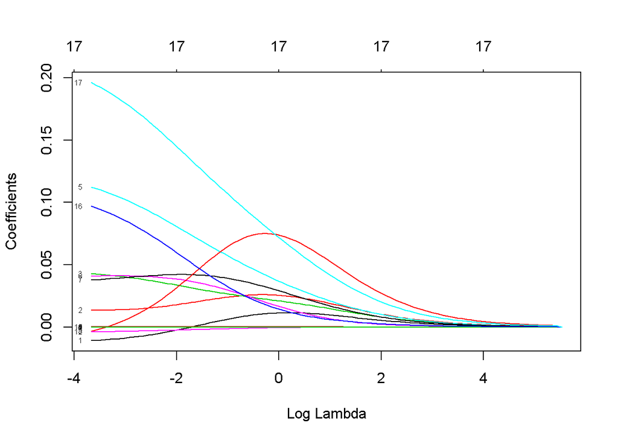

```r
y <- train$target
y <- as.integer(y)



# Para obtener un ajuste mediante ridge regression se indica argumento alpha=0.
modelos_ridge <- glmnet(x = x, y = y, alpha = 0)
plot(modelos_ridge, xvar = "lambda", label = TRUE)
```

Al aumentar el tamaño de los Lambda dismunuyen los coeficientes. Con el fin de identificar el valor de λ que da lugar al mejor modelo, se puede recurrir a Cross-Validation. La función cv.glmnet() calcula el cv-test-error, utilizando por defecto k=10.

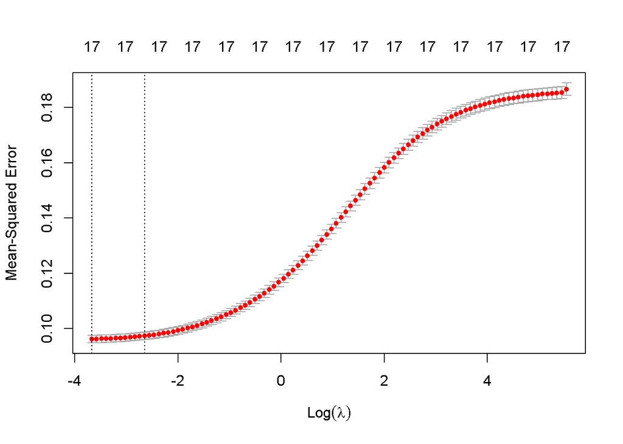

```r
set.seed(737)
cv_error_ridge <- cv.glmnet(x = x, y = y, alpha = 0, nfolds = 15,
                            type.measure = "mse")
plot(cv_error_ridge)
```

Podemos observar cómo varía el error cuadrático medio, en función del valor de regularización. Gráficamente se comprueba que el error no aumenta hasta que las variables con coeficiente mayor que cero es menor que -2, pero el menor error cuadrático medio se da para 17 variables regresoras y se mantiene constante. Es una de las grandes diferencias con Lasso.

```r
# Valor lambda con el que se consigue el mínimo test-error
cv_error_ridge$lambda.min
```

```
## [1] 0.02542122
```

```r
# Valor lambda óptimo: mayor valor de lambda con el que el test-error no se
# aleja más de 1 sd del mínimo test-error posible.
cv_error_ridge$lambda.1se
```

```
## [1] 0.07073607
```

```r
# Se muestra el valor de los coeficientes para el valor de lambda óptimo

modelo_final_ridge <- glmnet(x = x, y = y, alpha = 0, lambda = cv_error_ridge$lambda.1se)
coef(modelo_final_ridge)
```

```
## 18 x 1 sparse Matrix of class "dgCMatrix"
##                             s0
## (Intercept)       5.103194e+00
## bedrooms         -6.975913e-03
## bathrooms         1.508731e-02
## floors            3.821222e-02
## sqft_living       5.687788e-05
## grade             9.519157e-02
## condition         4.068419e-02
## view              4.076669e-02
## waterfront        1.292870e-02
## sqft_lot          4.959385e-08
## sqft_above        5.792261e-05
## sqft_basement     4.164063e-05
## yr_built         -3.164416e-03
## yr_renovated     -1.651793e-05
## sqft_living15     7.787366e-05
## sqft_lot15       -3.856229e-07
## Cluster_finalmed  7.737745e-02
## Cluster_finaltop  1.686181e-01
```

# Lasso

El método lasso, al igual que ridge regression, fuerza a que las estimaciones de los coeficientes de los predictores tiendan a cero. La diferencia es que lasso sí es capaz de fijar algunos de ellos exactamente a cero, lo que permite además de reducir la varianza, realizar selección de predictores. ∑i=1n(yi−β0−∑j=1pβjxij)2+λ∑j=1p|βj|=RSS+λ∑j=1p|βj|

Cuando solo un pequeño número de predictores de entre todos los incluidos tienen coeficientes sustanciales y el resto tienen valores muy pequeños o iguales a cero, lasso genera mejores modelos.

Selección del tunning parameter λ

```
Determinar el grado de penalización, seleccionamos un rango de valores de λ y se estima el cross-validation error resultante para cada uno, finalmente se selecciona el valor de λ para el que el error es menor y se ajusta de nuevo el modelo, esta vez empleando todas las observaciones.
```

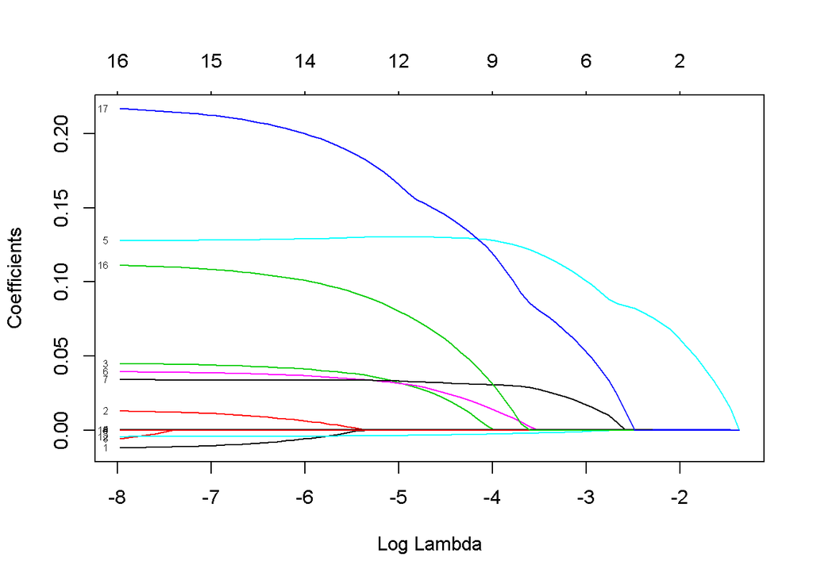

```r
modelos_lasso <- glmnet(x = x, y = y, alpha = 1)
plot(modelos_lasso, xvar = "lambda", label = TRUE)
```

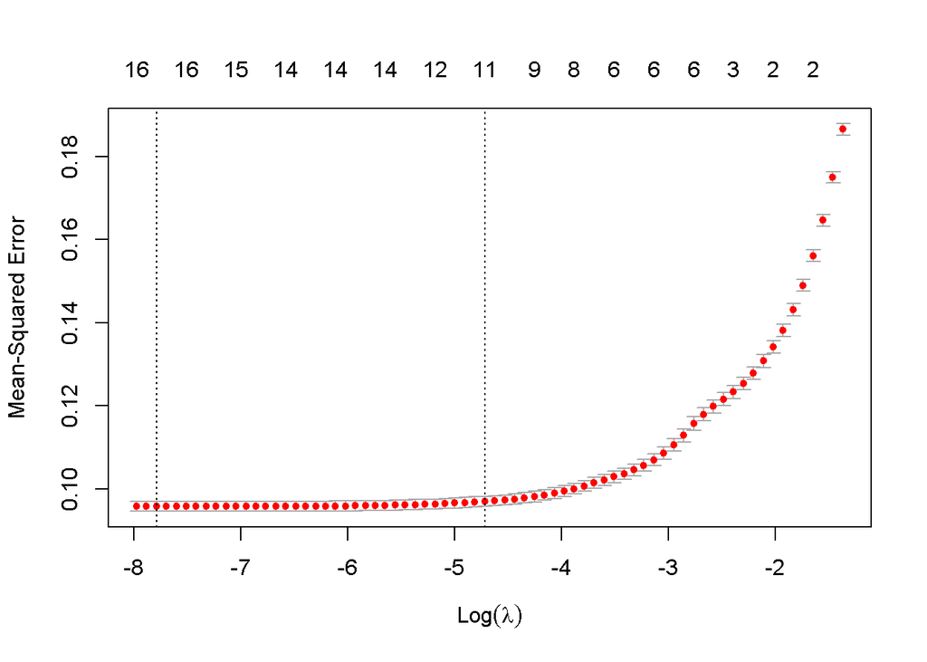

```r
set.seed(737)
cv_error_lasso <- cv.glmnet(x = x, y = y, alpha = 1, nfolds = 10)
plot(cv_error_lasso)
```

```r
cv_error_lasso$lambda.min
```

```
## [1] 0.0004143026
```

```r
cv_error_lasso$lambda.1se
```

```
## [1] 0.008925879
```

```r
# Se reajusta el modelo con todas las observaciones empleando el valor de
# lambda óptimo

modelo_final_lasso <- glmnet(x = x, y = y, alpha = 1, lambda = cv_error_lasso$lambda.1se)
coef(modelo_final_lasso)
```

```
## 18 x 1 sparse Matrix of class "dgCMatrix"
##                             s0
## (Intercept)       5.595800e+00
## bedrooms          .
## bathrooms         .
## floors            2.666460e-02
## sqft_living       9.143041e-05
## grade             1.300344e-01
## condition         2.862539e-02
## view              3.238449e-02
## waterfront        .
## sqft_lot          .
## sqft_above        6.118704e-06
## sqft_basement     .
## yr_built         -3.487305e-03
## yr_renovated      .
## sqft_living15     6.692732e-05
## sqft_lot15       -6.026306e-09
## Cluster_finalmed  7.061614e-02
## Cluster_finaltop  1.527260e-01
```

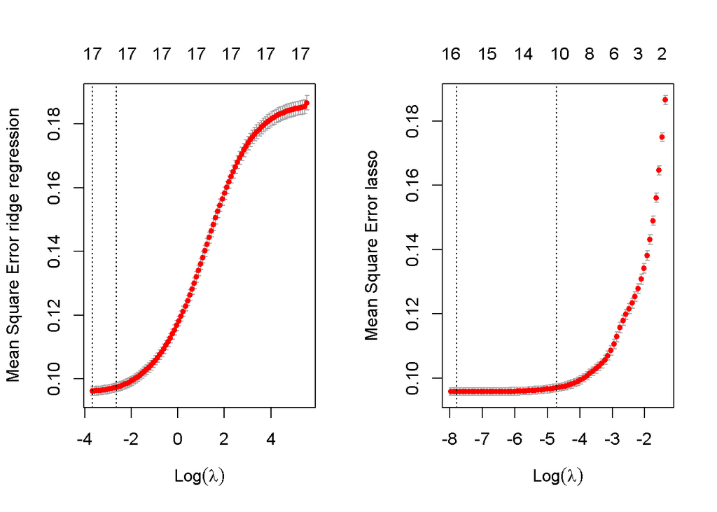

```r
par(mfrow = c(1,2))
plot(cv_error_ridge,ylab = "Mean Square Error ridge regression" )
abline(h = 120000)
plot(cv_error_lasso,ylab = "Mean Square Error lasso")
abline(h = 120000)
```

```r
par(mfrow = c(1,1))
```

# GAM link Logistic

### Modelo1 PostRegularización.

```r
# Modelo

model_gam_log1 <- gam (target~ s(lat,long) +s(sqft_living) + s(grade) + s( sqft_above)  + s(yr_built) + s(sqft_living15) +s(floors,k=3)+ s(view,k=3) + s(condition,k=3) + Cluster_final,
                       data=train, family =  binomial("logit"), method="REML")

summary(model_gam_log1)
```

```
##
## Family: binomial
## Link function: logit
##
## Formula:
## target ~ s(lat, long) + s(sqft_living) + s(grade) + s(sqft_above) +
##     s(yr_built) + s(sqft_living15) + s(floors, k = 3) + s(view,
##     k = 3) + s(condition, k = 3) + Cluster_final
##
## Parametric coefficients:
##                  Estimate Std. Error z value Pr(>|z|)
## (Intercept)      -3.55645    0.11039 -32.217  < 2e-16 ***
## Cluster_finalmed  0.06398    0.12515   0.511    0.609
## Cluster_finaltop  0.58369    0.14062   4.151 3.31e-05 ***
## ---
## Signif. codes:  0 '***' 0.001 '**' 0.01 '*' 0.05 '.' 0.1 ' ' 1
##
## Approximate significance of smooth terms:
##                     edf Ref.df  Chi.sq  p-value
## s(lat,long)      27.676 28.832 1314.56  < 2e-16 ***
## s(sqft_living)    3.511  4.307  186.23  < 2e-16 ***
## s(grade)          3.551  4.243  341.58  < 2e-16 ***
## s(sqft_above)     2.921  3.686  133.75  < 2e-16 ***
## s(yr_built)       5.702  6.901   88.74 2.88e-16 ***
## s(sqft_living15)  1.385  1.685   97.28  < 2e-16 ***
## s(floors)         1.000  1.001   44.85 2.14e-11 ***
## s(view)           1.890  1.988  178.15  < 2e-16 ***
## s(condition)      1.000  1.001  100.58  < 2e-16 ***
## ---
## Signif. codes:  0 '***' 0.001 '**' 0.01 '*' 0.05 '.' 0.1 ' ' 1
##
## R-sq.(adj) =  0.722   Deviance explained = 69.6%
## -REML = 2685.2  Scale est. = 1         n = 15117
```

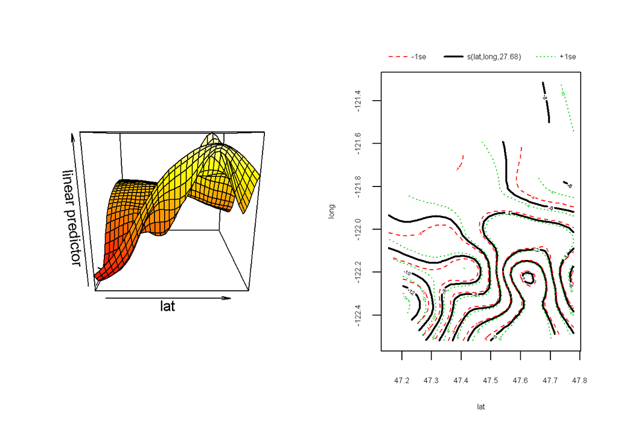

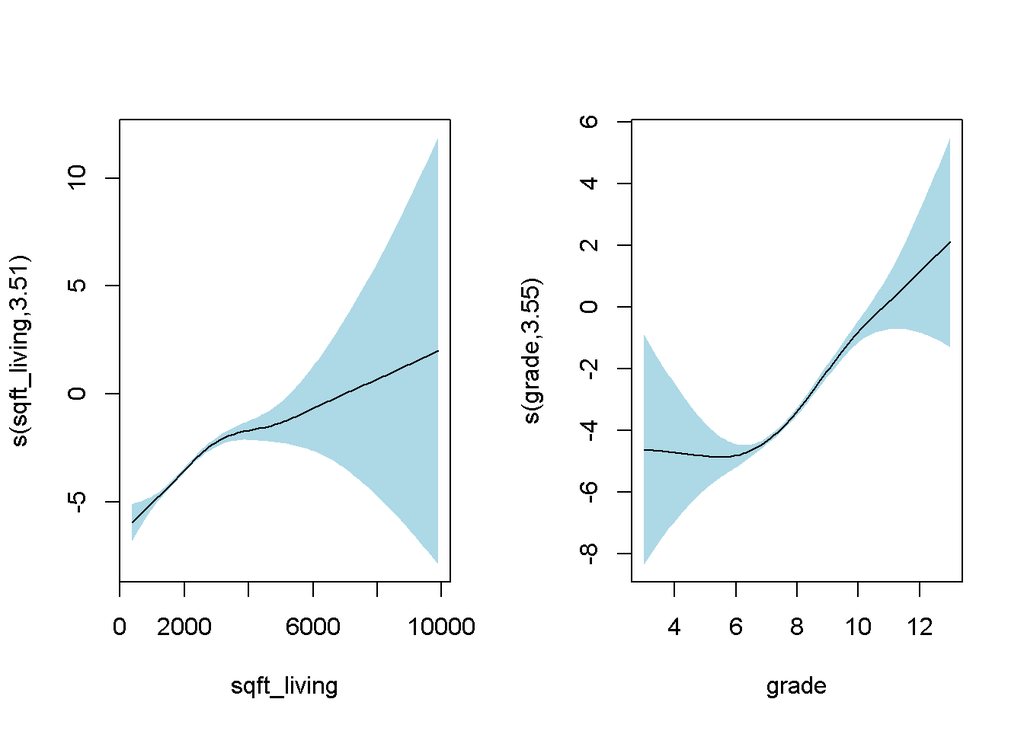

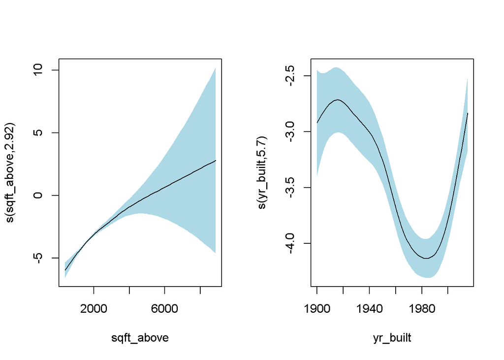

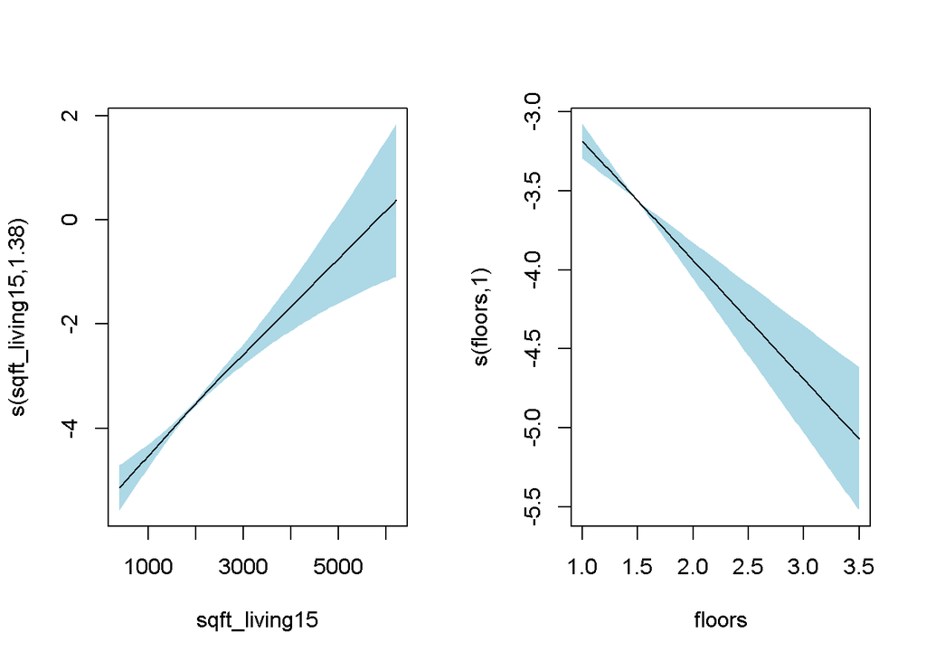

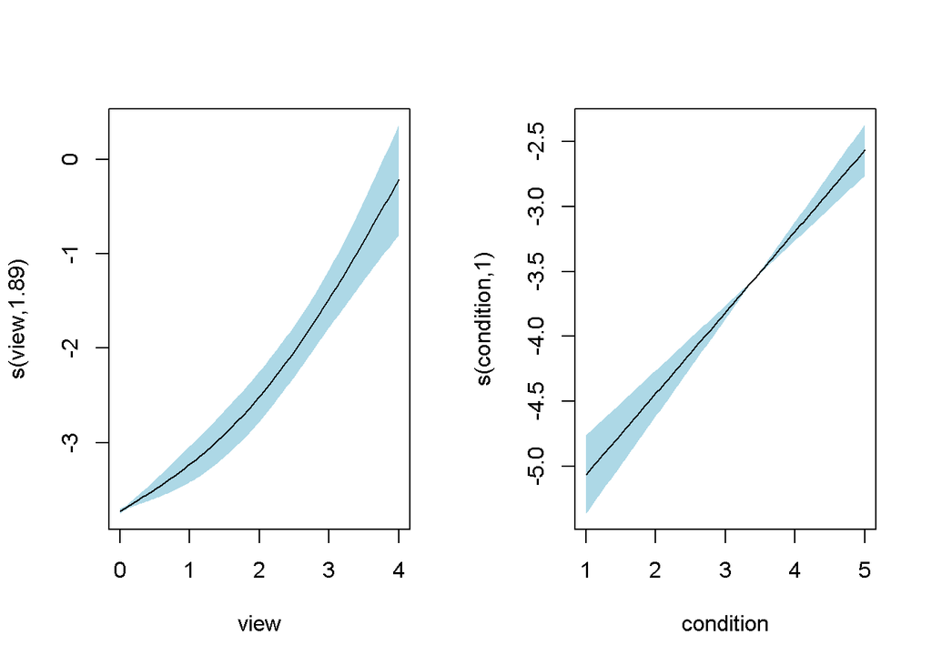

```r
layout(matrix(1:2, ncol = 2))
vis.gam (x=model_gam_log1,view=c("lat","long"),plot.type="persp")
plot(model_gam_log1, scale = 0,shade = TRUE, shade.col = "lightblue", shift=coef(model_gam_log1)[1])
```

Analizando la salida vamos tomar las siguiente decisiones:

##### 2.-Vemos que tenemos variables que son significativas pero que son lineales por lo que quitaremos la función smooth de ellas, y estudiaremos si son lienalmente significativas. Son: Condition y Floors. Quizá sqft_living15 también pudiera ser lineal pero de momento la vamos a mantener tal cual

### Modelo2 PostRegularización. Check Variables.

```r
# Modelo
train$Cluster_final <- relevel(train$Cluster_final, ref = "med")
model_gam_log2 <- gam (target~ s(lat,long) +s(sqft_living) + s(grade) + s( sqft_above)  + s(yr_built) + s(sqft_living15) +floors+ s(view,k=3) + condition + Cluster_final,
                       data=train, family =  binomial("logit"), method="REML")



summary(model_gam_log2)
```

```
##
## Family: binomial
## Link function: logit
##
## Formula:
## target ~ s(lat, long) + s(sqft_living) + s(grade) + s(sqft_above) +
##     s(yr_built) + s(sqft_living15) + floors + s(view, k = 3) +
##     condition + Cluster_final
##
## Parametric coefficients:
##                  Estimate Std. Error z value Pr(>|z|)
## (Intercept)      -4.50131    0.27763 -16.213  < 2e-16 ***
## floors           -0.75344    0.11250  -6.697 2.12e-11 ***
## condition         0.62474    0.06229  10.029  < 2e-16 ***
## Cluster_finallow -0.06398    0.12515  -0.511    0.609
## Cluster_finaltop  0.51971    0.11095   4.684 2.81e-06 ***
## ---
## Signif. codes:  0 '***' 0.001 '**' 0.01 '*' 0.05 '.' 0.1 ' ' 1
##
## Approximate significance of smooth terms:
##                     edf Ref.df  Chi.sq  p-value
## s(lat,long)      27.676 28.832 1314.56  < 2e-16 ***
## s(sqft_living)    3.511  4.307  186.23  < 2e-16 ***
## s(grade)          3.551  4.243  341.58  < 2e-16 ***
## s(sqft_above)     2.921  3.686  133.75  < 2e-16 ***
## s(yr_built)       5.702  6.901   88.74 2.87e-16 ***
## s(sqft_living15)  1.385  1.685   97.28  < 2e-16 ***
## s(view)           1.890  1.988  178.15  < 2e-16 ***
## ---
## Signif. codes:  0 '***' 0.001 '**' 0.01 '*' 0.05 '.' 0.1 ' ' 1
##
## R-sq.(adj) =  0.722   Deviance explained = 69.6%
## -REML = 2684.2  Scale est. = 1         n = 15117
```

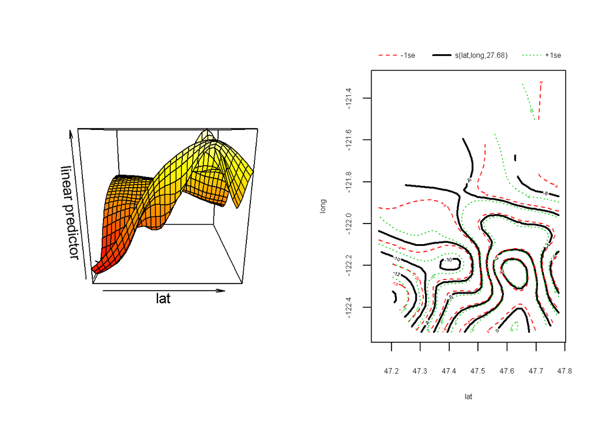

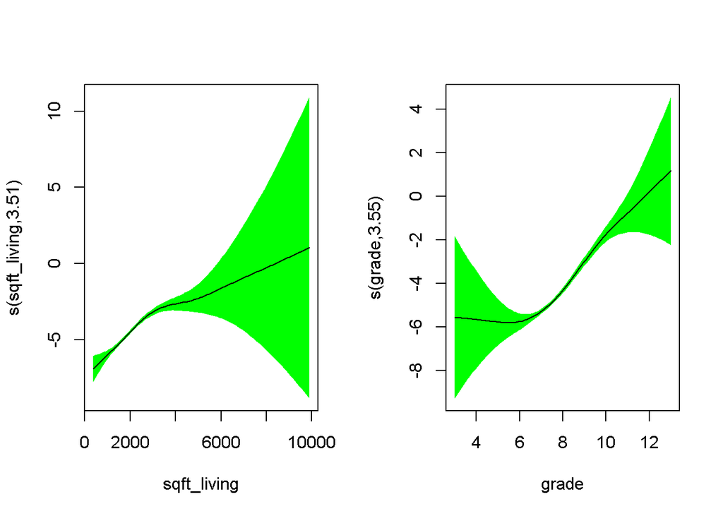

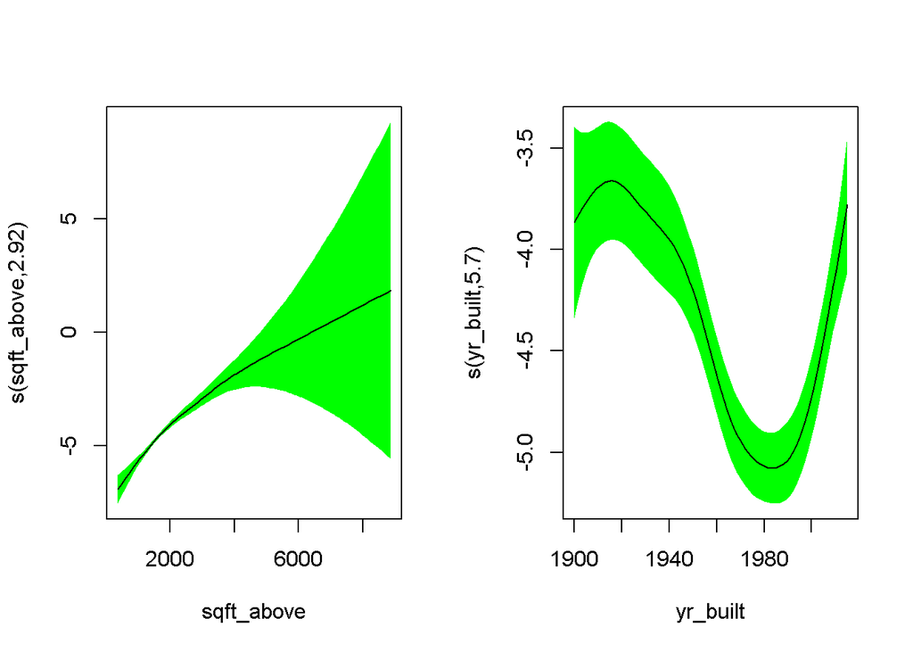

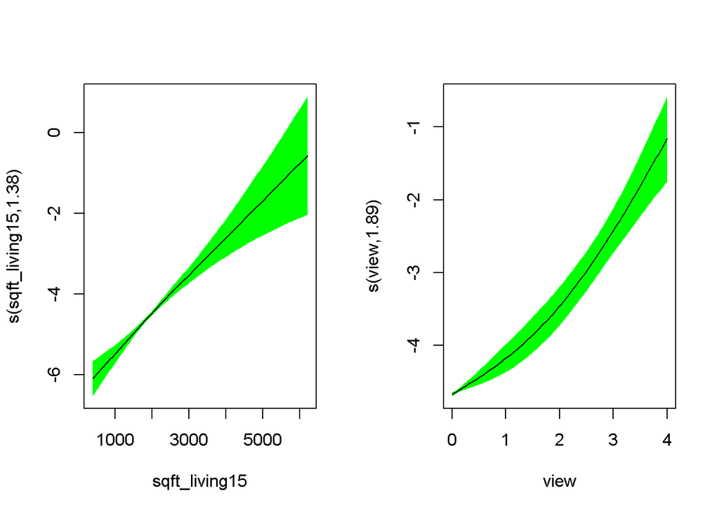

```r
layout(matrix(1:2, ncol = 2))
vis.gam (x=model_gam_log2,view=c("lat","long"),plot.type="persp")
plot(model_gam_log2, scale = 0,shade = TRUE, shade.col = "green" , shift=coef(model_gam_log2)[1])
```

Analizando la salida vamos tomar las siguiente decisiones:

##### 1.-No ha habido un gran cambio debido al cambio en la referencia del Clúster.

## checking concurvity Model 2 PostRegularización

La concurrencia ocurre cuando algún término suave en un modelo puede ser aproximado por uno o más de los otros términos suaves en el modelo. Este es a menudo el caso cuando se incluye una suavidad de espacio en un modelo, junto con suavidades de otros covariables que también varían más o menos suavemente en el espacio. Del mismo modo tiende ser un problema en modelos que incluyen un tiempo suave, junto con problemas de otro tiempo variando covariables.

Es esencialmente la forma no lineal de colinealidad, la library mgcv proporciona una medida de concurrencia y establece en la documentación si tales medidas están por encima de> 1.0 es preocupante. La literatura nos dice que se puede esperar concurvity con datos espaciales como es nuestro caso.

La concurrencia puede verse como una generalización de la co-linealidad y sus causas.

índices Relacionados Concurvity, todos entre [0,1]: 1.-Worst 2.-Observed 3.-Estimate

```r
# Check pairwise concurvity
k<-concurvity(model_gam_log2,full=FALSE)

#options(scipen=999)
k$worst
```

```
##                          para  s(lat,long) s(sqft_living)     s(grade)
## para             1.000000e+00 6.272121e-29   1.893096e-22 8.836600e-25
## s(lat,long)      1.469934e-28 1.000000e+00   1.741326e-01 2.190690e-01
## s(sqft_living)   1.892714e-22 1.741326e-01   1.000000e+00 6.243158e-01
## s(grade)         8.358696e-25 2.190690e-01   6.243158e-01 1.000000e+00
## s(sqft_above)    1.955502e-20 2.295885e-01   7.812821e-01 6.166542e-01
## s(yr_built)      4.238721e-22 4.133207e-01   1.670044e-01 2.805385e-01
## s(sqft_living15) 2.225614e-21 2.943536e-01   5.946669e-01 5.651612e-01
## s(view)          1.145192e-29 7.724145e-02   8.649223e-02 7.602690e-02
##                  s(sqft_above)  s(yr_built) s(sqft_living15)      s(view)
## para              1.955693e-20 4.236430e-22     2.224300e-21 1.185527e-29
## s(lat,long)       2.295885e-01 4.133207e-01     2.943536e-01 7.724145e-02
## s(sqft_living)    7.812821e-01 1.670044e-01     5.946669e-01 8.649223e-02
## s(grade)          6.166542e-01 2.805385e-01     5.651612e-01 7.602690e-02
## s(sqft_above)     1.000000e+00 2.753011e-01     5.586024e-01 3.200764e-02
## s(yr_built)       2.753011e-01 1.000000e+00     1.492657e-01 4.915959e-03
## s(sqft_living15)  5.586024e-01 1.492657e-01     1.000000e+00 8.124622e-02
## s(view)           3.200764e-02 4.915959e-03     8.124622e-02 1.000000e+00
```

No existen variables con Concurvity significatica.

## Matriz de Confusión GAM binary para la población Validation

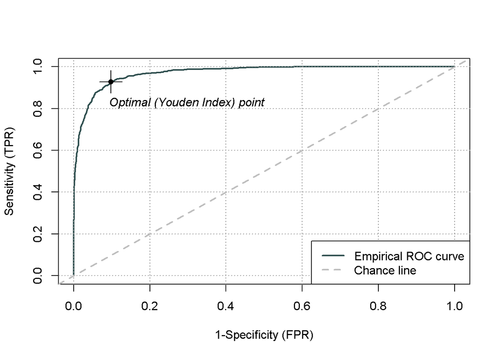

```r
predictions_val <- predict(model_gam_log2, validation,type='response')

## Warning: package 'ROCit' was built under R version 3.5.2
ROCit_obj <- rocit(score=predictions_val,class=validation$target)
plot(ROCit_obj)
```

```r
table(pred = predictions_val > 0.5, obs = validation$target)
```

```
##        obs
## pred       0    1
##   FALSE 3110  190
##   TRUE   134  886
```

```r
data = as.numeric(predictions_val>0.5)
data=as.factor(data)
y_test=as.factor(validation$target)

# use caret and compute a confusion matrix
confusionMatrix(data, y_test)
```

```
## Confusion Matrix and Statistics
##
##           Reference
## Prediction    0    1
##          0 3110  190
##          1  134  886
##
##                Accuracy : 0.925
##                  95% CI : (0.9167, 0.9327)
##     No Information Rate : 0.7509
##     P-Value [Acc > NIR] : < 2.2e-16
##
##                   Kappa : 0.796
##
##  Mcnemar's Test P-Value : 0.002246
##
##             Sensitivity : 0.9587
##             Specificity : 0.8234
##          Pos Pred Value : 0.9424
##          Neg Pred Value : 0.8686
##              Prevalence : 0.7509
##          Detection Rate : 0.7199
##    Detection Prevalence : 0.7639
##       Balanced Accuracy : 0.8911
##
##        'Positive' Class : 0
##
```

## GAINS and Lift Chart

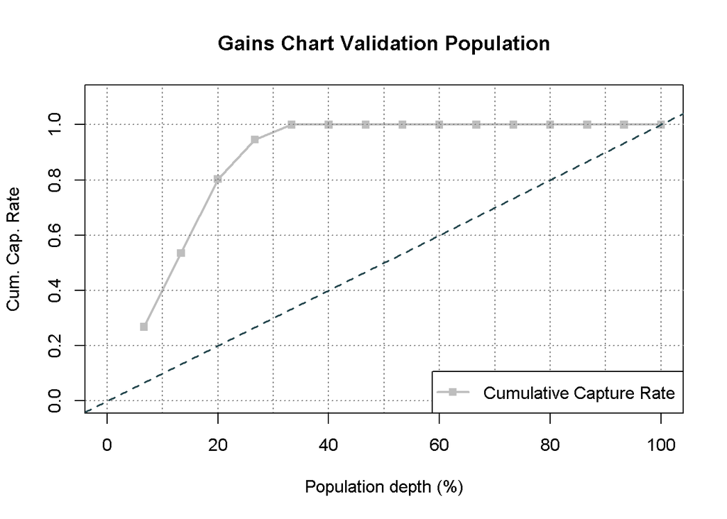

```r
data = as.numeric(predictions_val>0.5)
gtable15 <- gainstable(score = data,
                       class = validation$target,

                       ngroup = 15)


plot(gtable15, type = 3,main='')
title(main = "Gains Chart Validation Population")
```

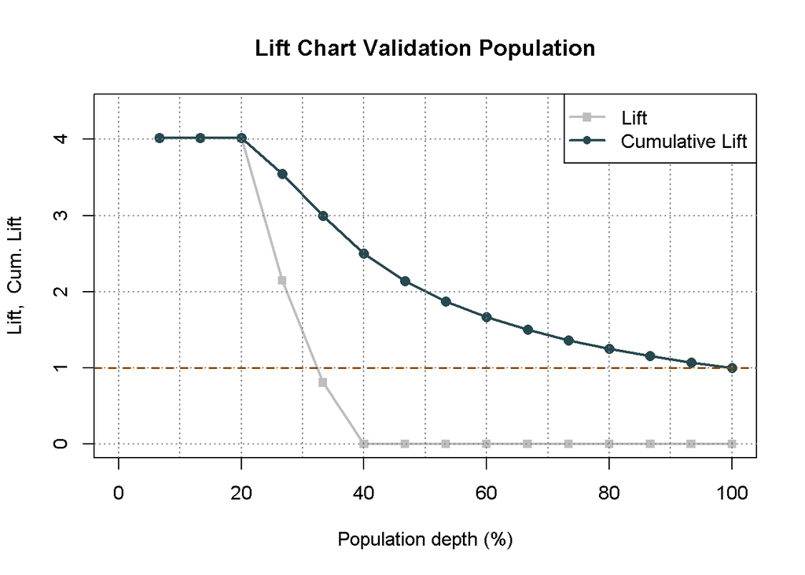

```r
plot(gtable15, type = 1)
title(main = "Lift Chart Validation Population")
```